# An Anyalsis Of The Housing Market

2025-08-17

The housing market in the U.S is very vital to understand. Those with the finical ability to acquire a house are investing in an asset that they perceive will one day grow in value. The money behind a housing purchase is not small and with such a large purchase it is important to understand the forces that drive the prices of that asset. This report will detail historic price drivers in the housing market along with the current force that is pushing prices.

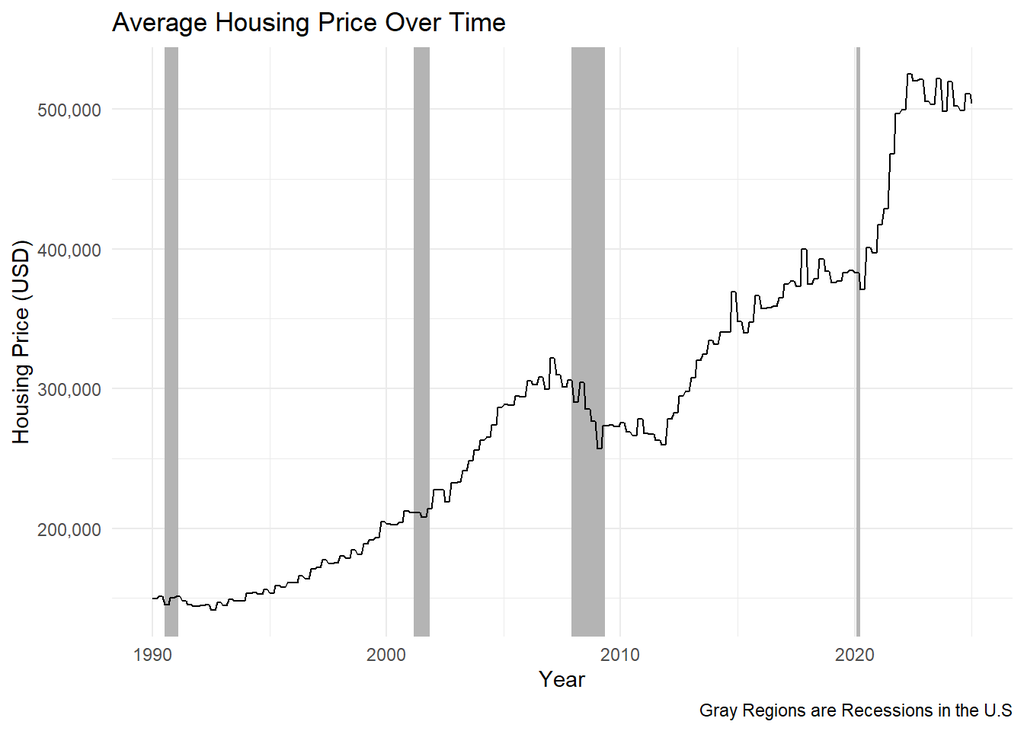

Below are two graphs that show how economic uncertainty and unemployment fluctuate with prices. While there is some short run volatility there is no relationship between these two and the long run trend of increasing housing prices. Overall, these two can be used to describe the health of the macroeconomy and only when the macroeconomy is in a recession may we see a short run relationship. However, we see that during two recessions the prices of the housing market continued to rise and as such the fall in prices during the great recession was not due to the macroeconomy but rather the collapse of a force driving up the prices.

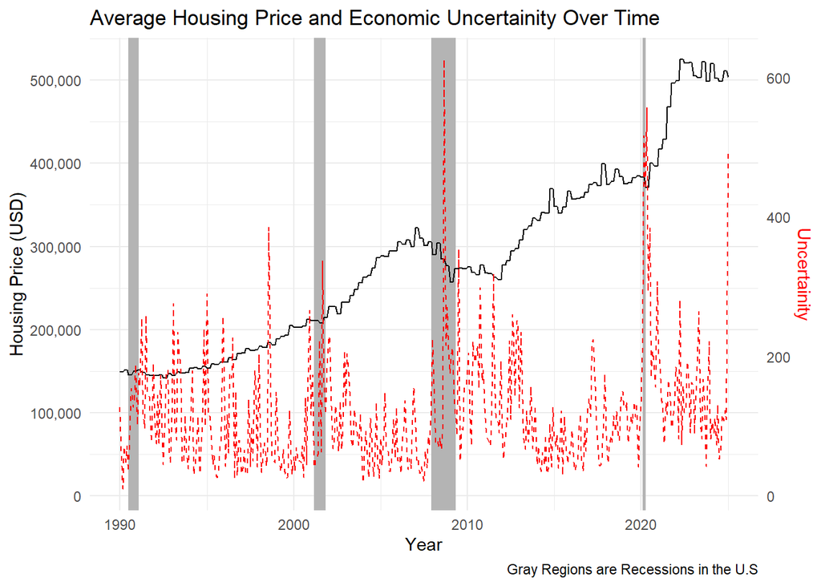

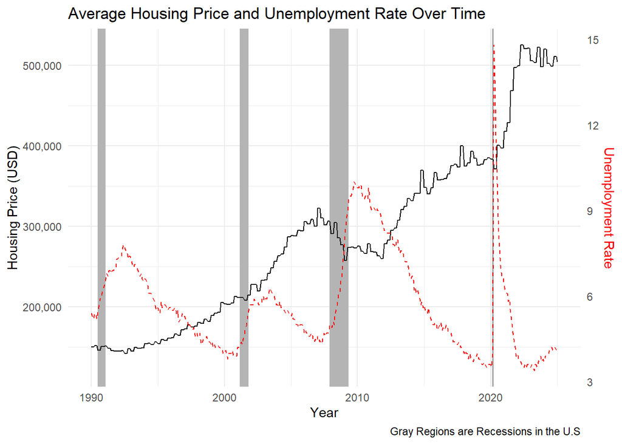

# The Housing Bubble

From 1990-2007 the housing market was in a bubble. In a normal market the price of a good is at the equilibrium found between supply and demand. People’s demand is inversely related to price, i.e if a good is priced higher than less people will want it. Firms want to price their goods as high as possible so the price is positively related to price. The intersection of the supply of good and the demand for them is called the market equilibrium and the forces of the market push that price to be at that level. This concept is critically to the state of the housing market during this time.

There are two graphs below that focus on the supply fluctuations on the market but this analysis will focus on the period of 1990-2007 which was before the great recession. The graph below shows how the supply of houses fluctuates over time. The black line is how many new houses are created, and the red line is the ratio of the new houses created divided by the new houses sold. These two values give us a clear insight into the supply and demand. We see from 1990 to 2000 that new houses keep being introduced to the market. While the physical supply of houses is increasing, it is important to note that when a house is bought it is removed from the market. So, if 1 new house is built a day but 2 houses are bought that day then the supply is actually falling. The ratio of the new houses to new houses sold captures this value. We see that during the period of 1990 to 2000 that the ratio is falling and as such can conclude that there is no supply issue in this market during this time. What we can conclude from this is that holding demand constant the housing prices should only increase slightly at the rate of inflation.

While from 2000-2005 the number of houses entering the market has fallen the stability in the ratio shows that on the supply side there is not a disbalance in the market. However, from 2005 onwards we see a lot of houses enter the market and after that we see a massive spike in the ratio. This means that there are more new houses in the market than ones being bought, in other words we should have a housing surplus holding demand constant. When the supply is greater than demand we expect the prices of houses to fall.

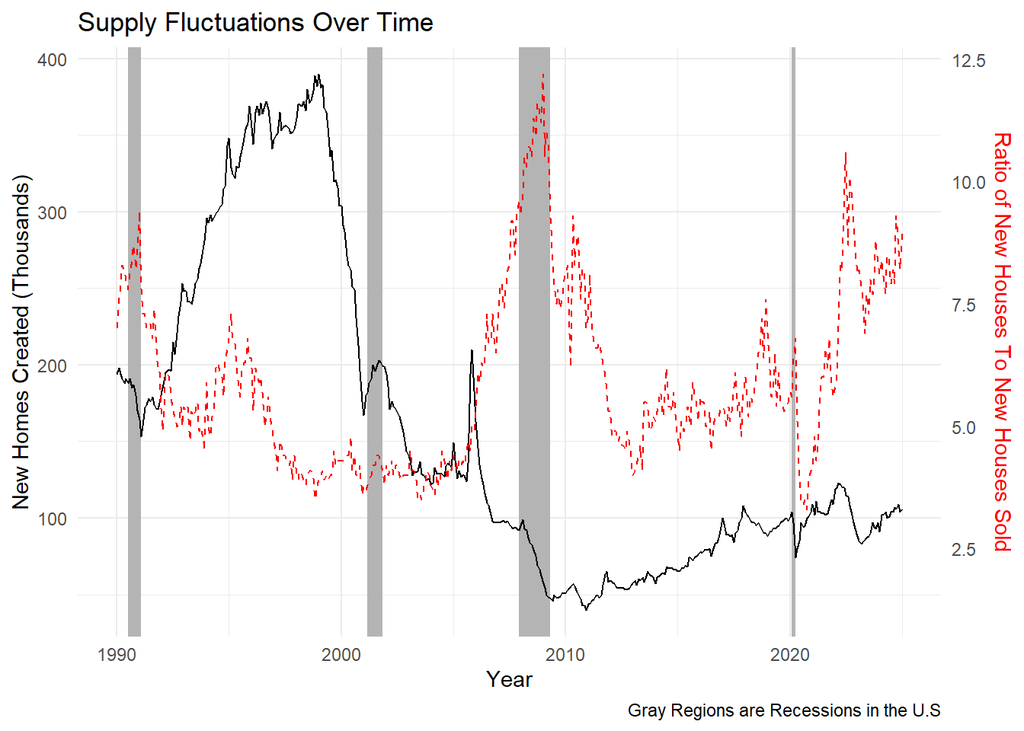

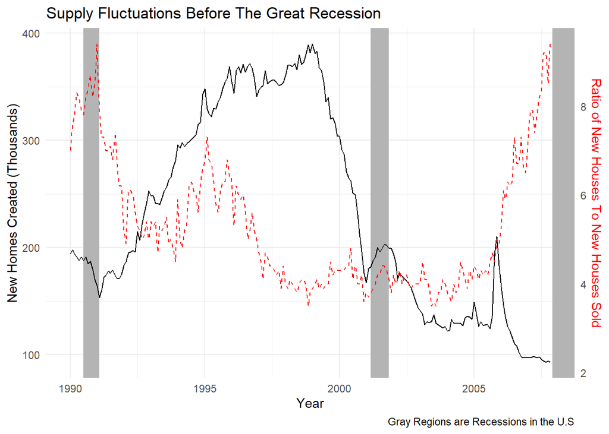

In our previous analysis we held demand constant and the below graph shows why this assumption is valid. People buy a home to live in it and so we can proxy the homeownership rate as a measure of need. We infer a stable market to proxy need as demand. Some people cannot buy homes because they do not have the means hence, we cannot expect the rate to be at 100%. Instead, as more people grow up and can buy homes if there is a higher demand for homeownership then the rate will be pushed upwards. Since the fluctuations in the rate are small we can presume that throughout this period the demand for people with the means to buy a home has remained the same.

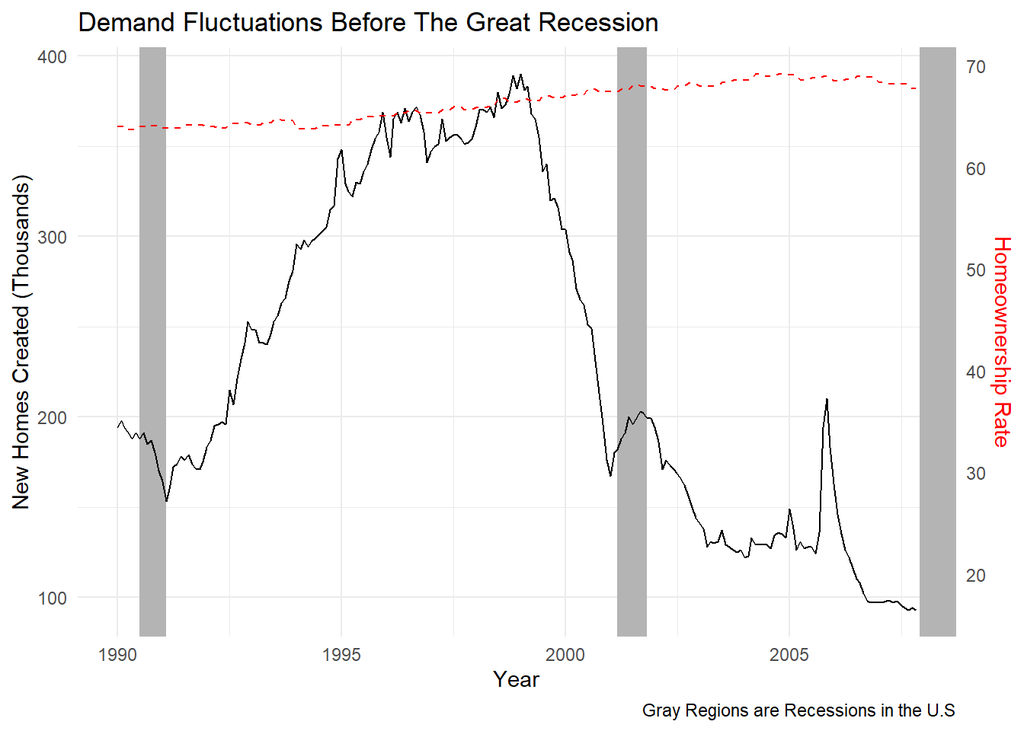

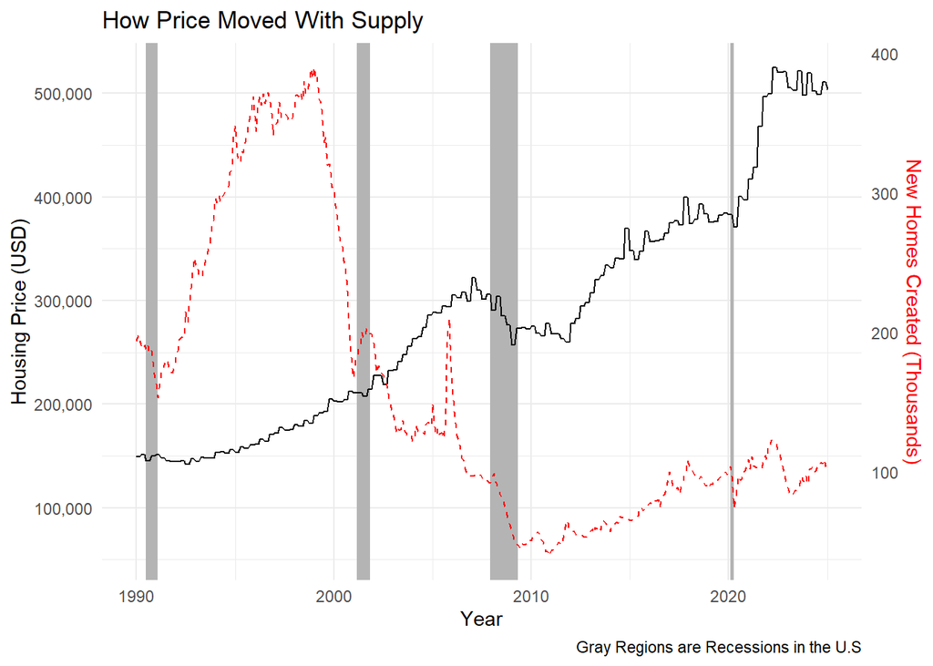

This is a pivotal piece of history in the housing market and outlines that the movements in the housing market is not inherently related to business cycles since we now see that this is the reason that prices fell during the great recession. However, the most important reason to understand this is that it shows blindly looking at the trends in housing prices over time without considering other forces will result in the wrong picture. While housing prices are currently rising we must look at the underlying forces to see if that trend will continue.

# The Current Market

In recent years the Covid 19 pandemic uprooted everything and the economy was no exception. Even though it started five years ago it’s impacts are still felt to this day and the current state of the housing market is a perfect example of this. While business cycles do not impact the long run prices of the housing market that is not to say it is not impacted by the macro economy. The market is subject to inflation and during the Covid 19 pandemic inflation grew immensely. As such part of the increase in the prices in the housing market can be linked to this element. However, this report will detail the other driving force behind the housing market prices.

Below is a graph that in black shows the homeownership rate over time and in red shows the occupied housing units. We can represent the homeownership rate as (number of people who own homes) / (total number of people). A change in the homeownership rate can be modeled by (existing homeowners + new homeowners) / (total number of people). If we look at the trend depicted in the graph we see that the number of occupied homes increases with respect to time and assuming the majority of those changes comes from first time home owners we would expect the home ownership rate to increase. However, this is not occurring and that is because the total population is also increasing. The key element to analyze is not the volume but instead how the population of people and houses grows and move together over time.

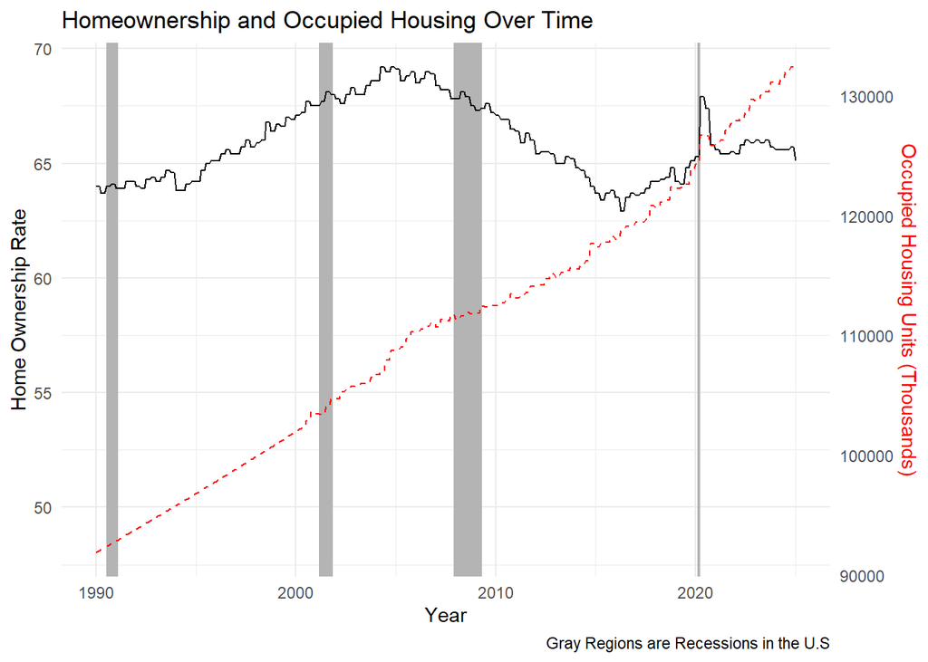

Focusing on analyzing the relationship between the homeownership rate and occupied houses, the two graphs below are snapshots of two different periods. In the first period of 2017-2020 we see the homeownership rate is moving with the occupied houses. Meaning that the number of people buying homes is outpacing the number of people entering the population. Yet in 2020-2025 we do not see the same picture. The homeownership has a brief spike due to the pandemic pushing people to buy more homes but the homeownership rate quickly falls. The number of occupied houses continues to grow which would suggest that the population growth has outpaced the growth of the housing market. This suggestion has two vital implications that involve the context of covid to illuminate. 1. During the pandemic population growth was very low meaning that a greater negative impact to the supply of homes had to occur for this relationship to appear. 2. Covid disrupted supply chains everywhere stalling the construction of houses. These factors illuminate that the number of houses in the market has drastically fallen meaning that unlike the housing bubble there is an actual supply demand disbalance in the market. The supply of houses is not meeting the demand for houses which is called a shortage and is an upward pressure on prices. Meaning that if situations stay constant the housing market will continue to surge in prices.

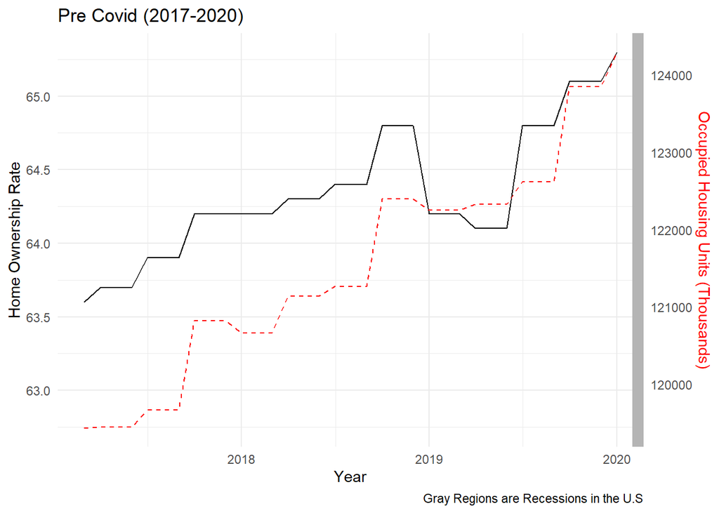

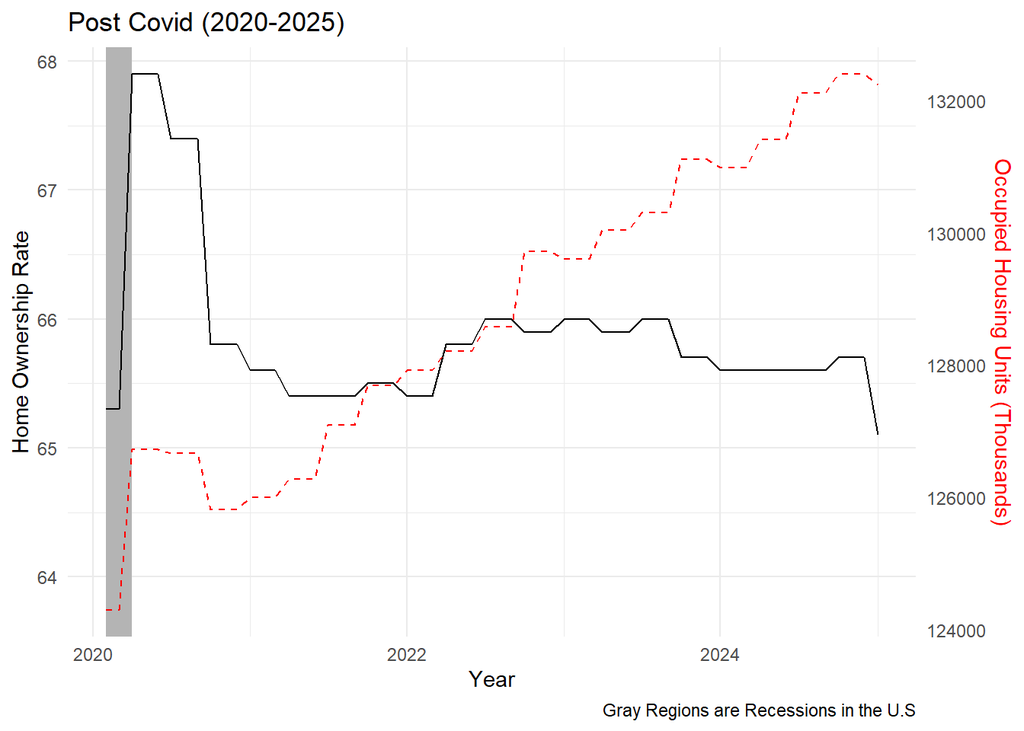

# Should a House be bought:

Purchasing a house during a bubble is unwise however, we are not in those conditions right now. The market is currently boosted by high inflation and a shortage. Currently terrible economic policies run rampant and inflation seems like it will only continue to rise. However, the fate of the shortage is unknown. It does seem like there are more houses being introduced to the market and the prices might begin to fall. It is potentially a risk to buy many houses right now due to instability and the shortage potentially dropping prices. If one is in need of a house and wants to buy one right now then it is not an unwise decision but one could also wait and see if the shortage can be meet and in term drop prices.